# Introduction to NIMBLE

Ken Kellner

**What is NIMBLE/`nimble`?**:

- Software for fitting statistical models (de Valpine et al., 2017)
- Best-known for Bayesian analysis
- Modeling language (BUGS-based)
- Algorithm language

# Outline

1. Simulate dataset
2. The BUGS language
3. Simple `nimble` workflow
4. Customized `nimble` workflow
5. Other algorithms
6. Macros

# Simulate dataset

- Probability of wolf occurrence at a site
- Probability depends on forest cover
- Ignore imperfect detection

[figure not shown]

## Simulation

First some design and covariate data:

```r
set.seed(1)
M <- 100 # number of sites
forest <- runif(M, 0, 100)
forest_scale <- as.numeric(scale(forest))
```

Calculate occurrence probability $\psi$:

$$\mu_i = \beta_0 + \beta_1 \cdot forest_i $$

$$ \psi_i = \mathrm{ilogit}(\mu_i) $$

```r
beta0 <- qlogis(0.3) # average occurrence is 0.3
beta1 <- 0.5 # positive effect of forest
truth <- c(beta0=beta0, beta1=beta1)
```

```r
mu <- psi <- numeric(M)
for (i in 1:M){
  mu[i] <- beta0 + beta1 * forest_scale[i]
  psi[i] <- plogis(mu[i])
}
```

Simulate observed data $y$:

$$ y_i \sim \mathrm{Binomial}(\psi_i, 1) $$

```r
y <- numeric(M)
for (i in 1:M){
  y[i] <- rbinom(1, 1, psi[i]) # simulate random Bernoulli
}
y
```

1. 0

2. 0

3. 0

4. 1

5. 0

6. 0

7. 0

8. 0

9. 1

10. 0

11. 1

12. 0

13. 0

14. 0

15. 0

16. 0

17. 1

18. 1

19. 0

20. 1

21. 1

22. 0

23. 0

24. 0

25. 0

26. 0

27. 0

28. 0

29. 0

30. 0

31. 0

32. 0

33. 0

34. 0

35. 1

36. 0

37. 0

38. 0

39. 1

40. 0

41. 1

42. 0

43. 0

44. 0

45. 1

46. 0

47. 0

48. 1

49. 0

50. 1

51. 0

52. 1

53. 0

54. 0

55. 0

56. 0

57. 0

58. 0

59. 0

60. 0

61. 0

62. 1

63. 0

64. 1

65. 1

66. 0

67. 0

68. 0

69. 0

70. 0

71. 0

72. 1

73. 1

74. 0

75. 0

76. 1

77. 1

78. 0

79. 1

80. 1

81. 0

82. 0

83. 1

84. 0

85. 1

86. 0

87. 1

88. 0

89. 1

90. 0

91. 0

92. 0

93. 0

94. 1

95. 0

96. 1

97. 0

98. 1

99. 0

100. 1

## Visualize simulated dataset

Start by breaking up the response data into categories by forest cover

```r
breaks <- quantile(forest, c(0, 0.2, 0.4, 0.6, 0.8, 1))
forest_cat <- cut(forest, breaks = breaks)
tab <- aggregate(y ~ forest_cat, FUN=mean)
tab$n <- table(forest_cat)
tab$se <- sqrt(tab[,2] * (1-tab[,2]) / tab$n)
```

Plot the forest - occurrence relationship

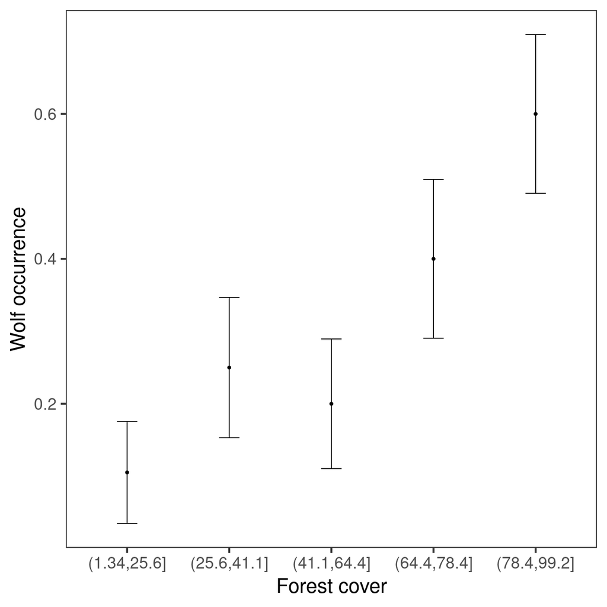

```r
library(ggplot2)
options(repr.plot.width=10, repr.plot.height=10)

ggplot(data = tab) +
  geom_point(aes(x=forest_cat, y = y)) +
  geom_errorbar(aes(x = forest_cat, ymin= y - se, ymax=y + se), width=0.2) +
  labs(y = "Wolf occurrence", x = "Forest cover") +
  theme_bw(base_size = 24) +
  theme(panel.grid = element_blank())
```

## Fit the model with `glm`

```r
fit_glm <- glm(y ~ forest_scale, family=binomial)
summary(fit_glm)

est_glm <- coef(fit_glm)
```

```
Call:
glm(formula = y ~ forest_scale, family = binomial)

Coefficients:
             Estimate Std. Error z value Pr(>|z|)
(Intercept)   -0.9741     0.2524  -3.859 0.000114 ***
forest_scale   0.9806     0.2683   3.654 0.000258 ***
---
Signif. codes:  0 ‘***’ 0.001 ‘**’ 0.01 ‘*’ 0.05 ‘.’ 0.1 ‘ ’ 1

(Dispersion parameter for binomial family taken to be 1)

    Null deviance: 123.82  on 99  degrees of freedom
Residual deviance: 107.45  on 98  degrees of freedom
AIC: 111.45

Number of Fisher Scoring iterations: 4
```

# The BUGS language

- Used mainly (but not exclusively) for Bayesian analysis
- Defines relationships between *nodes*
- Nodes may be data or parameters to estimate
- Model consists of *declarations* about nodes
- Nodes declared deterministic using `<-`
- or coming from a probability distribution (using `~`)

```
x <- 2 + 2
y <- alpha + beta
z ~ dnorm(0, 1)
```

- Order of declarations generally doesn't matter (resulting in a directed acyclic graph or DAG)

## BUGS Code for the model

Data nodes: `M`, `y`, `forest_scale`

Parameter nodes: `beta0`, `beta1`, `mu`, `psi`

```
# Likelihood
for (i in 1:M){
  # Calculate linear predictor
  mu[i] <- beta0 + beta1 * forest_scale[i]

  # Transform it to a probability
  logit(psi[i]) <- mu[i]
  #psi[i] <- ilogit(mu[i]) # equivalent

  # Data model
  y[i] ~ dbern(psi[i])
  #y[i] ~ dbinom(psi[i], 1) # equivalent
}

# Priors (uninformative/vague)
beta0 ~ dnorm(0, sd = 10)
beta1 ~ dnorm(0, sd = 10)
```

# Simple `nimble` workflow

1. Create list of data
2. Write BUGS code with `nimbleCode`
3. Set parameters to monitor
4. Run `nimbleMCMC`
5. Do things with the output

```r
library(nimble)
```

1. Create list of data

```r
nimble_data <- list(M = M, forest_scale = forest_scale, y = y)
```

2. Write BUGS code

```r
code <- nimbleCode({
  # Likelihood
  for (i in 1:M){
    mu[i] <- beta0 + beta1 * forest_scale[i]
    logit(psi[i]) <- mu[i]

    y[i] ~ dbern(psi[i])
  }

  # Priors
  beta0 ~ dnorm(0, sd = 10)
  beta1 ~ dnorm(0, sd = 10)
})
```

```r
code
```

```
{
    for (i in 1:M) {
        mu[i] <- beta0 + beta1 * forest_scale[i]
        logit(psi[i]) <- mu[i]
        y[i] ~ dbern(psi[i])
    }
    beta0 ~ dnorm(0, sd = 10)
    beta1 ~ dnorm(0, sd = 10)
}
```

3. Set parameters to monitor

```r
pars <- c("beta0", "beta1")
```

4. Run `nimbleMCMC`

```r
fit_nimble <- nimbleMCMC(code = code,
                         constants = nimble_data,
                         monitors = pars,
                         niter = 2000,
                         nburnin = 1000,
                         nchains = 3,
                         samplesAsCodaMCMC = TRUE)
```

```
Defining model

  [Note] Using 'y' (given within 'constants') as data.

Building model

Setting data and initial values

Running calculate on model
  [Note] Any error reports that follow may simply reflect missing values in model variables.

Checking model sizes and dimensions

  [Note] This model is not fully initialized. This is not an error.
         To see which variables are not initialized, use model$initializeInfo().
         For more information on model initialization, see help(modelInitialization).

Checking model calculations

[Note] NAs were detected in model variables: beta0, logProb_beta0, beta1, logProb_beta1, mu, psi, logProb_y.

Compiling
  [Note] This may take a minute.
  [Note] Use 'showCompilerOutput = TRUE' to see C++ compilation details.

running chain 1...
```

```
|-------------|-------------|-------------|-------------|
|-------------------------------------------------------|
```

```
running chain 2...
```

```
|-------------|-------------|-------------|-------------|
|-------------------------------------------------------|
```

```
running chain 3...
```

```
|-------------|-------------|-------------|-------------|
|-------------------------------------------------------|
```

## 5. Do things with the output

Look at the basic structure of the output object

```r
class(fit_nimble)
lapply(fit_nimble, head)
```

'mcmc.list'

```
$chain1
Markov Chain Monte Carlo (MCMC) output:
Start = 1
End = 7
Thinning interval = 1
          beta0    beta1
[1,] -1.2447419 1.151105
[2,] -1.1334599 1.151105
[3,] -1.1334599 1.151105
[4,] -1.1334599 1.151105
[5,] -0.8809714 1.151105
[6,] -0.8809714 1.151105
[7,] -1.2971098 1.151105

$chain2
Markov Chain Monte Carlo (MCMC) output:
Start = 1
End = 7
Thinning interval = 1
          beta0     beta1
[1,] -0.9408710 1.4288127
[2,] -0.9408710 0.5757906
[3,] -0.9408710 0.5757906
[4,] -1.0350197 0.5757906
[5,] -1.0350197 0.5757906
[6,] -0.6750462 1.1591206
[7,] -1.2717070 1.4231754

$chain3
Markov Chain Monte Carlo (MCMC) output:
Start = 1
End = 7
Thinning interval = 1
          beta0     beta1
[1,] -1.2882755 0.9003846
[2,] -0.8214824 0.9003846
[3,] -0.8214824 0.9003846
[4,] -0.8214824 1.1800996
[5,] -0.8214824 1.1800996
[6,] -0.9494132 1.1800996
[7,] -0.9494132 1.2342609
```

### Model diagnostics

Using the `coda` package (`MCMCvis` is also a good option that Chris will show tomorrow)

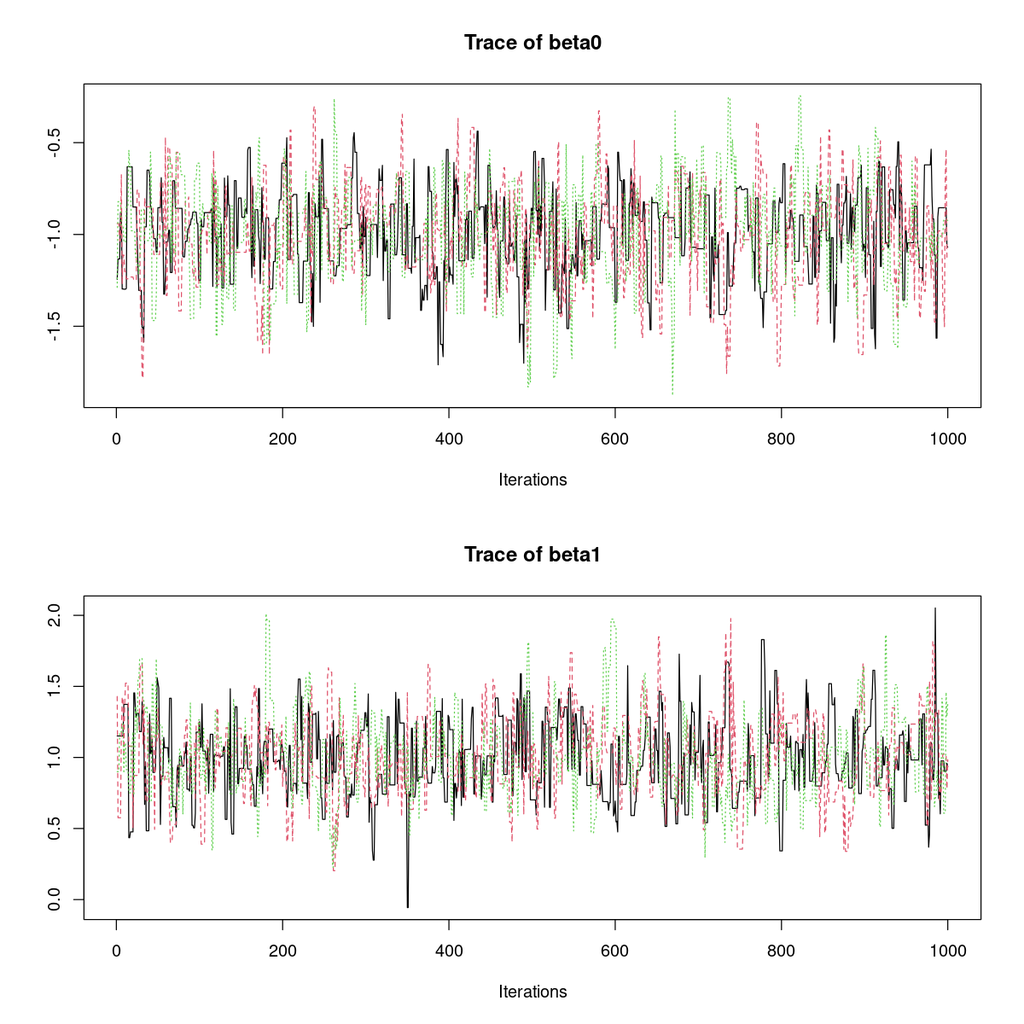

```r
par(mfrow=c(2,1))
coda::traceplot(fit_nimble)
```

```r
# R-hat
coda::gelman.diag(fit_nimble)
```

```
Potential scale reduction factors:

      Point est. Upper C.I.
beta0       1.02       1.05
beta1       1.01       1.03

Multivariate psrf

1.01
```

```r
# Effective sample size
coda::effectiveSize(fit_nimble)
```

**beta0**

582.071541687761

**beta1**

614.644590788453

### Inference

```r
summary(fit_nimble)
```

```
Iterations = 1:1000
Thinning interval = 1
Number of chains = 3
Sample size per chain = 1000

1. Empirical mean and standard deviation for each variable,
   plus standard error of the mean:

         Mean     SD Naive SE Time-series SE
beta0 -0.9953 0.2554 0.004663        0.01060
beta1  1.0044 0.2818 0.005145        0.01187

2. Quantiles for each variable:

         2.5%     25%     50%     75%   97.5%
beta0 -1.5319 -1.1543 -0.9898 -0.8275 -0.5354
beta1  0.4842  0.8111  1.0004  1.1900  1.6033
```

Look at the posterior distributions

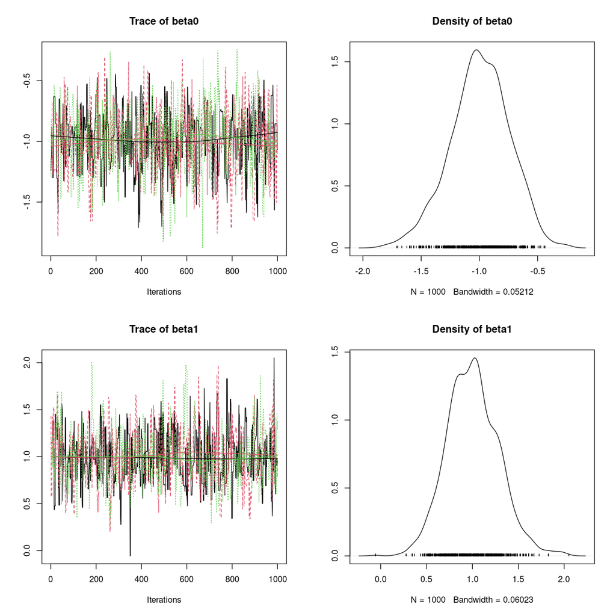

```r
plot(fit_nimble)
```

Compare estimates

```r
est_nimble <- apply(as.matrix(fit_nimble), 2, mean)
comp <- cbind(truth = truth, glm = est_glm, nimble = est_nimble)
round(comp, 3)
```

A matrix: 2 × 3 of type dbl

|  | truth | glm | nimble |
| --- | --- | --- | --- |
| beta0 | -0.847 | -0.974 | -0.995 |
| beta1 | 0.500 | 0.981 | 1.004 |

## Create a figure from the output

We'll make a figure that shows the relationship between forest and occurrence probability as a smooth curve.

First, convert the posterior samples into a matrix:

```r
post <- as.matrix(fit_nimble)
dim(post)
head(post)
```

1. 3000

2. 2

A matrix: 6 × 2 of type dbl

| beta0 | beta1 |
| --- | --- |
| -1.2447419 | 1.151105 |
| -1.1334599 | 1.151105 |
| -1.1334599 | 1.151105 |
| -1.1334599 | 1.151105 |
| -0.8809714 | 1.151105 |
| -0.8809714 | 1.151105 |

Make the x-axis of the plot, a sequence of forest values:

```r
n <- 100
forest_rng <- range(forest)
forest_seq <- seq(forest_rng[1], forest_rng[2], length.out = n)
head(forest_seq)
forest_seq_scale <- (forest_seq - mean(forest)) / sd(forest)
```

1. 1.33903331588954

2. 2.32743307515377

3. 3.315832834418

4. 4.30423259368223

5. 5.29263235294646

6. 6.28103211221069

For each value of `forest_seq_scale`, calculate a posterior distribution for the corresponding value of `psi`:

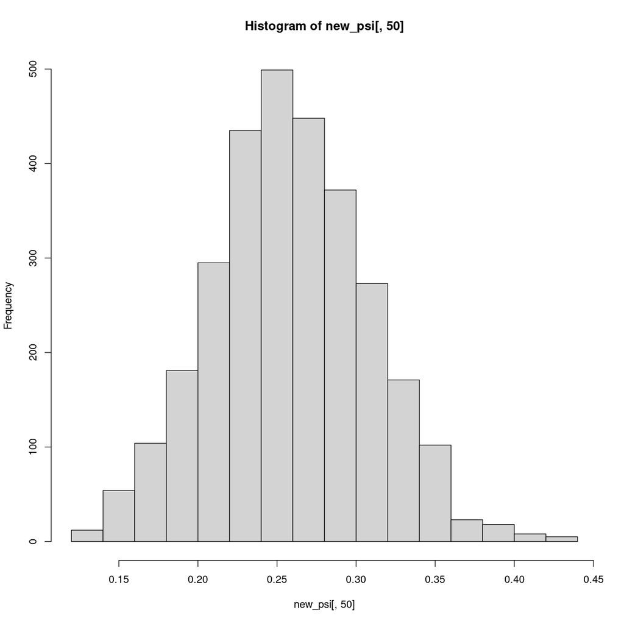

```r
new_psi <- matrix(NA, nrow = nrow(post), ncol = n)

# Iterate over MCMC samples
for (i in 1:nrow(post)){
  # Iterate over forest values
  for (j in 1:n){
    # Calculate psi
    new_psi[i, j] <- plogis(post[i, "beta0"] + post[i, "beta1"] * forest_seq_scale[j])
  }
}

# posterior for 50th value of forest_seq
hist(new_psi[,50])
```

Calculate posterior summary stats for each value of `forest_seq`

```r
plot_dat <- data.frame(
  forest = forest_seq,
  psi = apply(new_psi, 2, mean),
  low = apply(new_psi, 2, quantile, 0.025),
  high = apply(new_psi, 2, quantile, 0.975)
)

head(plot_dat)
```

A data.frame: 6 × 4

|  | forest <dbl> | psi <dbl> | low <dbl> | high <dbl> |
| --- | --- | --- | --- | --- |
| 1 | 1.339033 | 0.06250830 | 0.01291872 | 0.1589271 |
| 2 | 2.327433 | 0.06437100 | 0.01364472 | 0.1618014 |
| 3 | 3.315833 | 0.06629135 | 0.01443600 | 0.1651010 |
| 4 | 4.304233 | 0.06827107 | 0.01531733 | 0.1671360 |
| 5 | 5.292632 | 0.07031191 | 0.01625158 | 0.1689846 |
| 6 | 6.281032 | 0.07241566 | 0.01713792 | 0.1708495 |

Use the data frame of summary stats to make a plot:

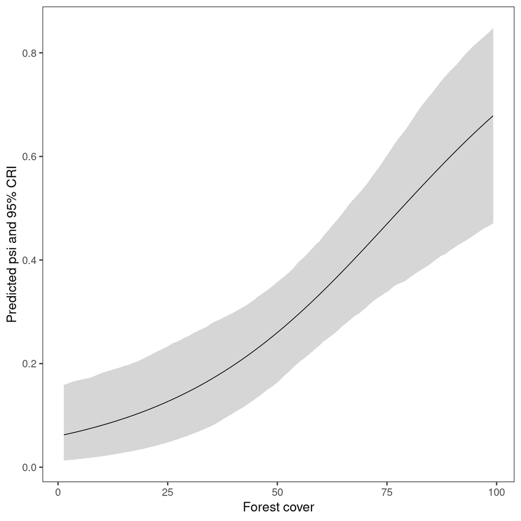

```r
ggplot(data = plot_dat) +
  geom_ribbon(aes(x = forest, ymin = low, ymax = high), alpha=0.2) +
  geom_line(aes(x = forest, y = psi)) +
  labs(x = "Forest cover", y = "Predicted psi and 95% CRI") +
  theme_bw(base_size = 18) +
  theme(panel.grid = element_blank())
```

Now also show the "true" relationship between forest and $\psi$

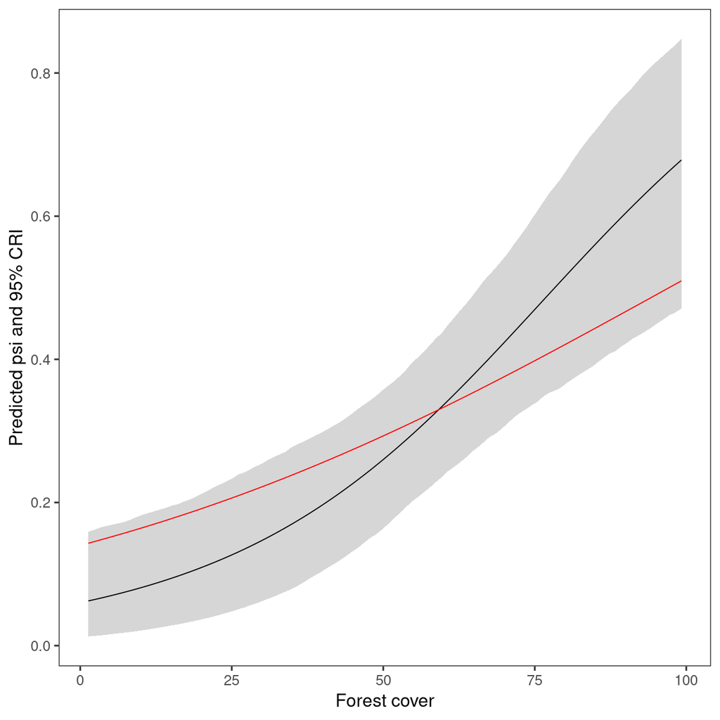

```r
true_line <- data.frame(x = forest, y = psi)
ggplot(data = plot_dat) +
  geom_ribbon(aes(x = forest, ymin = low, ymax = high), alpha=0.2) +
  geom_line(aes(x = forest, y = psi)) +
  geom_line(data = true_line, aes(x=forest, y = psi), col='red') +
  labs(x = "Forest cover", y = "Predicted psi and 95% CRI") +
  theme_bw(base_size = 18) +
  theme(panel.grid = element_blank())
```

# Customized `nimble` workflow

- Done in several steps instead of just one step (`nimbleMCMC`)
- Allows for more control

Workflow:

1. Create `nimbleModel` object
2. Configure MCMC
3. Create MCMC object
4. Compile model and MCMC
5. Run analysis

## 1. Create `nimbleModel` object

We will explicitly initialize our two parameters in this example

```r
inits <- list(beta0 = 0, beta1 = 0)
```

```r
# Create a NIMBLE model from BUGS code
r_model <- nimbleModel(code = code, constants = nimble_data,
                       inits = inits)
```

```
Defining model

  [Note] Using 'y' (given within 'constants') as data.

Building model

Setting data and initial values

Running calculate on model
  [Note] Any error reports that follow may simply reflect missing values in model variables.

Checking model sizes and dimensions
```

What's contained in the model object?

```r
r_model$getCode()
```

```
{
    for (i in 1:M) {
        mu[i] <- beta0 + beta1 * forest_scale[i]
        logit(psi[i]) <- mu[i]
        y[i] ~ dbern(psi[i])
    }
    beta0 ~ dnorm(0, sd = 10)
    beta1 ~ dnorm(0, sd = 10)
}
```

```r
r_model$y
r_model$beta0
```

1. 0

2. 0

3. 0

4. 1

5. 0

6. 0

7. 0

8. 0

9. 1

10. 0

11. 1

12. 0

13. 0

14. 0

15. 0

16. 0

17. 1

18. 1

19. 0

20. 1

21. 1

22. 0

23. 0

24. 0

25. 0

26. 0

27. 0

28. 0

29. 0

30. 0

31. 0

32. 0

33. 0

34. 0

35. 1

36. 0

37. 0

38. 0

39. 1

40. 0

41. 1

42. 0

43. 0

44. 0

45. 1

46. 0

47. 0

48. 1

49. 0

50. 1

51. 0

52. 1

53. 0

54. 0

55. 0

56. 0

57. 0

58. 0

59. 0

60. 0

61. 0

62. 1

63. 0

64. 1

65. 1

66. 0

67. 0

68. 0

69. 0

70. 0

71. 0

72. 1

73. 1

74. 0

75. 0

76. 1

77. 1

78. 0

79. 1

80. 1

81. 0

82. 0

83. 1

84. 0

85. 1

86. 0

87. 1

88. 0

89. 1

90. 0

91. 0

92. 0

93. 0

94. 1

95. 0

96. 1

97. 0

98. 1

99. 0

100. 1

0

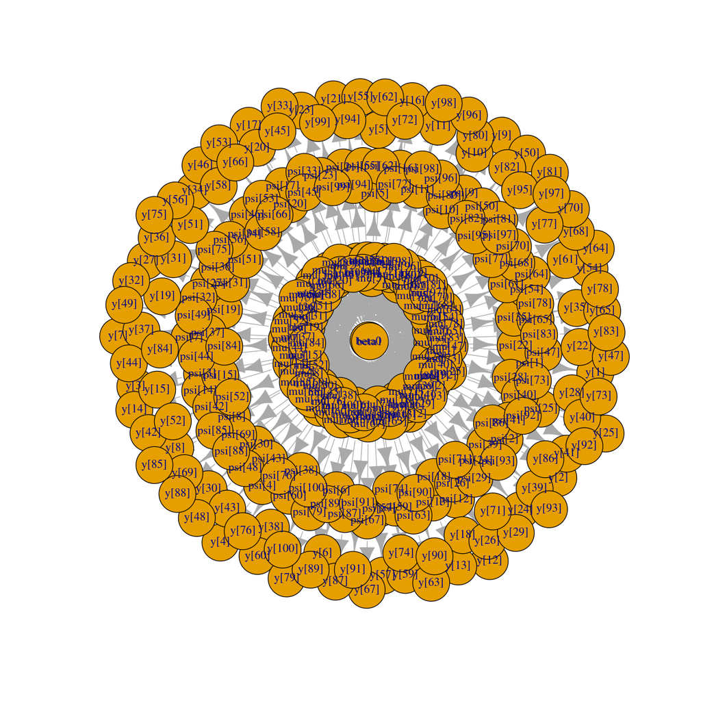

```r
# The DAG, which is not very helpful in this case
plot(r_model$modelDef$graph)
```

## 2. Configure MCMC

Create an MCMC configuration using `nimble`'s defaults

The default is Metropolis-Hastings random walk samplers for our parameters

```r
mcmc_config <- configureMCMC(r_model, monitors = pars)
```

```
===== Monitors =====
thin = 1: beta0, beta1
===== Samplers =====
RW sampler (2)
  - beta0
  - beta1
```

## 3. Build the MCMC

```r
r_mcmc <- buildMCMC(mcmc_config)
```

Technically we can now sample using the MCMC object, but it's very slow.

```r
system.time(r_mcmc$run(10))
as.matrix(r_mcmc$mvSamples)
```

```
   user  system elapsed
  1.732   0.000   1.733
```

A matrix: 10 × 2 of type dbl

| beta0 | beta1 |
| --- | --- |
| -0.6846853 | 0.7228268 |
| -0.6846853 | 0.7228268 |
| -1.0552395 | 0.7228268 |
| -1.0552395 | 0.7228268 |
| -1.0552395 | 1.1935780 |
| -1.0552395 | 1.1935780 |
| -1.0552395 | 1.3404854 |
| -1.2968958 | 1.3404854 |
| -0.7811458 | 1.3404854 |
| -0.7811458 | 1.3404854 |

## 4. Compile the model and MCMC sampler

`nimble` converts our R code to C++, which is then compiled to fast machine code

```r
c_model <- compileNimble(r_model)
c_mcmc <- compileNimble(r_mcmc, project = r_model) # note project argument
```

```
Compiling
  [Note] This may take a minute.
  [Note] Use 'showCompilerOutput = TRUE' to see C++ compilation details.

Compiling
  [Note] This may take a minute.
  [Note] Use 'showCompilerOutput = TRUE' to see C++ compilation details.
```

Now we can sample much faster:

```r
system.time(c_mcmc$run(10))
```

```
   user  system elapsed
  0.001   0.000   0.001
```

## 5. Run the analysis

We'll run multiple chains, and we want to initialize each chain differently.

```r
inits <- function(){
  list(beta0 = rnorm(1), beta1 = rnorm(1))
}
inits()
```

**$beta0**

1.55774951974462

**$beta1**

-0.916808478595012

```r
inits()
```

**$beta0**

1.5965758241783

**$beta1**

-0.836315940674406

The `runMCMC` function generates the final samples using options similar to `nimbleMCMC`.

```r
samples <- runMCMC(c_mcmc, inits = inits, nchains = 3, niter = 2000, nburnin = 1000,
                   samplesAsCodaMCMC = TRUE)

summary(samples)
```

```
running chain 1...
```

```
|-------------|-------------|-------------|-------------|
|-------------------------------------------------------|
```

```
running chain 2...
```

```
|-------------|-------------|-------------|-------------|
|-------------------------------------------------------|
```

```
running chain 3...
```

```
|-------------|-------------|-------------|-------------|
|-------------------------------------------------------|
```

```
Iterations = 1:1000
Thinning interval = 1
Number of chains = 3
Sample size per chain = 1000

1. Empirical mean and standard deviation for each variable,
   plus standard error of the mean:

         Mean     SD Naive SE Time-series SE
beta0 -0.9944 0.2625 0.004793        0.01166
beta1  1.0130 0.2649 0.004835        0.01024

2. Quantiles for each variable:

         2.5%     25%     50%     75%   97.5%
beta0 -1.5476 -1.1547 -0.9791 -0.8148 -0.4843
beta1  0.5122  0.8285  1.0041  1.1723  1.5490
```

# Other algorithms

Examples:

- Hamiltonian Monte Carlo (HMC)
- Laplace approximation
- Pólya-Gamma sampler

## HMC

- Used most famously by `Stan`.
- Reduces correlation between successive samples (thus increasing effective sample size)
- Each iteration generally slower `nimble`'s default samplers
- Requires calculating gradients (derivatives) and thus, practically, automatic differentation (AD)
- Certain kinds of models are more complicated to fit (such as models with latent variables like occupancy)

```r
library(nimbleHMC)
```

Start by building a new model object, and specifying that we'll need derivative capabilities

```r
r_model <- nimbleModel(code = code, constants = nimble_data, buildDerivs = TRUE)
```

```
Defining model

  [Note] Using 'y' (given within 'constants') as data.

Building model

Setting data and initial values

Running calculate on model
  [Note] Any error reports that follow may simply reflect missing values in model variables.

Checking model sizes and dimensions

  [Note] This model is not fully initialized. This is not an error.
         To see which variables are not initialized, use model$initializeInfo().
         For more information on model initialization, see help(modelInitialization).
```

Configure an HMC sampler and build it:

```r
hmc_config <- configureHMC(r_model, monitors = pars)
r_hmc <- buildMCMC(hmc_config)
```

```
===== Monitors =====
thin = 1: beta0, beta1
===== Samplers =====
NUTS sampler (1)
  - beta0, beta1
```

NUTS stands for "No U-Turn Sampler" which is a type of HMC (that Stan also uses)

Compile the model and sampler, same as before:

```r
c_model <- compileNimble(r_model)
c_hmc <- compileNimble(r_hmc, project = r_model)
```

```
Compiling
  [Note] This may take a minute.
  [Note] Use 'showCompilerOutput = TRUE' to see C++ compilation details.

Compiling
  [Note] This may take a minute.
  [Note] Use 'showCompilerOutput = TRUE' to see C++ compilation details.
```

Take samples same as before.

```r
samples_hmc <- runMCMC(c_hmc, inits = inits, nchains = 3, niter = 2000, nburnin = 1000,
                      samplesAsCodaMCMC = TRUE)

summary(samples_hmc)
```

```
running chain 1...
```

```
  [Note] NUTS sampler (nodes: beta0, beta1) is using 1000 warmup iterations.
         Since `warmupMode` is 'default' and `nburnin` > 0,
         the number of warmup iterations is equal to `nburnin`.
         The burnin samples will be discarded, and all samples returned will be post-warmup.
|-------------|-------------|-------------|-------------|
|-------------------------------------------------------|
```

```
running chain 2...
```

```
|-------------|-------------|-------------|-------------|
|-------------------------------------------------------|
```

```
running chain 3...
```

```
|-------------|-------------|-------------|-------------|
|-------------------------------------------------------|
```

```
Iterations = 1:1000
Thinning interval = 1
Number of chains = 3
Sample size per chain = 1000

1. Empirical mean and standard deviation for each variable,
   plus standard error of the mean:

         Mean     SD Naive SE Time-series SE
beta0 -0.9916 0.2561 0.004675       0.006347
beta1  1.0085 0.2722 0.004969       0.006731

2. Quantiles for each variable:

         2.5%     25%     50%     75%  97.5%
beta0 -1.5110 -1.1570 -0.9822 -0.8173 -0.505
beta1  0.5037  0.8146  0.9997  1.1860  1.568
```

As expected, our effective sample size will be higher than with the default sampler:

```r
round(coda::effectiveSize(samples_hmc))
round(coda::effectiveSize(samples)) # MH-RW has fewer effective samples
```

**beta0**

1630

**beta1**

1671

**beta0**

524

**beta1**

675